# EDA 01

```r
library(dplyr)
library(ggplot2)
library(readr)
library(magrittr)
dir("../../data")
trade <- read_csv("../../data/Trade.csv")
isin <- read_csv("../../data/Isin.csv")
challenge <- read_csv("../../data/Challenge_20180423.csv")
dim(trade)
colnames(trade)
```

```r
sapply(trade, function(col) length(unique(col)))
```

```
    TradeDateKey      CustomerIdx          IsinIdx          BuySell      NotionalEUR            Price      TradeStatus
             684             3439            27305                2          1796119            95768                5
CustomerInterest
               2
```

```r
f_cuenta_prop <- function(variable) {
    tabla <- table(trade[[variable]])
    rbind(tabla, round(prop.table(tabla),3))
}
list(f_cuenta_prop("BuySell"), f_cuenta_prop("TradeStatus"), f_cuenta_prop("CustomerInterest"))
```

```
[[1]]
              Buy        Sell
tabla 3695951.000 3066070.000
            0.547       0.453

[[2]]
            Done     Holding       IOI  NotTraded     Unknown
tabla 731815.000 4550092.000 15495.000 293175.000 1171444.000
           0.108       0.673     0.002      0.043       0.173

[[3]]
                0           1
tabla 4550092.000 2211929.000
            0.673       0.327
```

## Holding

De la descripción de la data, el interés del cliente es 0 solo si su estatus es holding. Podriamos obtener bastante informacion explorando la naturaleza de Holding en relacion a Customer / IsinIdx / Trade?

#### Proporcion de holding segun cliente

```r
trade %>%
    group_by(CustomerIdx) %>%
    summarise(prop_holding = mean(TradeStatus == "Holding"), cuenta = n()) %>%
    arrange(desc(prop_holding))
```

| CustomerIdx | prop_holding | cuenta |
| --- | --- | --- |
| 1946 | 0.9999496843 | 39749 |
| 2104 | 0.9999198252 | 49891 |
| 2888 | 0.9999198252 | 49891 |
| 227 | 0.9999181736 | 12221 |
| 2064 | 0.9999179296 | 36554 |
| 370 | 0.9998835720 | 8589 |
| 600 | 0.9998819780 | 8473 |
| 1888 | 0.9998774059 | 16314 |
| 2304 | 0.9998093422 | 5245 |
| 2675 | 0.9997965412 | 4915 |

[output cut: 990 more lines]

#### Holding x cliente

[output not shown]

[output cut: 990 more lines]

- Esto se demora tanto porque se generan todas las posibles combinaciones (poco mas del tamaño de trade)
- Hace pensar en que la cantidad de determinado Isin que tiene el cliente no es explicita; sin embargo deberia cambiar con el tiempo si el cliente compra/vende. Habria que explorar NotionalEur a traves del tiempo.

#### Holding segun cliente x fecha

```r
hold_customer_x_fecha <- trade %>%
                group_by(CustomerIdx, TradeDateKey) %>%
                summarise(prop_holding = mean(TradeStatus == "Holding"), cuenta = n()) %>%
                arrange(desc(prop_holding))
hold_customer_x_fecha
```

| CustomerIdx | TradeDateKey | prop_holding | cuenta |
| --- | --- | --- | --- |
| 10 | 20160101 | 1 | 688 |
| 10 | 20160331 | 1 | 182 |
| 10 | 20160630 | 1 | 116 |
| 10 | 20160930 | 1 | 132 |
| 10 | 20161231 | 1 | 131 |
| 10 | 20170331 | 1 | 118 |
| 10 | 20170630 | 1 | 102 |
| 10 | 20170930 | 1 | 93 |
| 10 | 20171231 | 1 | 103 |
| 19 | 20160101 | 1 | 201 |

[output cut: 990 more lines]

- Se observa lo que vio Robert de Holding ocurriendo a fines/comienzos de mes.
- Sin embargo, hay holdings que no ocurren solo en esas fechas. Son estos los eventos que nos interesan?

[figure not shown]

```r
library(lubridate)
library(stringr)
regex_no_fin_mes <- "[0-9]{6}((28)|(29)|(30)|(31)|(01))"
hold_customer_x_fecha %>%
    filter(TradeDateKey > 20180000) %>%
    filter(!str_detect(TradeDateKey, regex_no_fin_mes)) %>%
    mutate(TradeDateKey = lubridate::ymd(TradeDateKey)) %>%
    ggplot() +
    geom_jitter(aes(x = prop_holding, y = cuenta, color = TradeDateKey), alpha=0.5)
```

Que veo aqui?

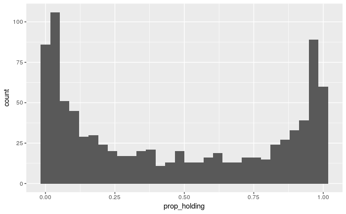

```r
hold_customer_x_fecha %>%
    filter(!str_detect(TradeDateKey, regex_no_fin_mes)) %>%
    ungroup() %>% count(prop_holding) %>%
    ggplot() +
    geom_histogram(aes(x=prop_holding))
```

## Customer x Isin

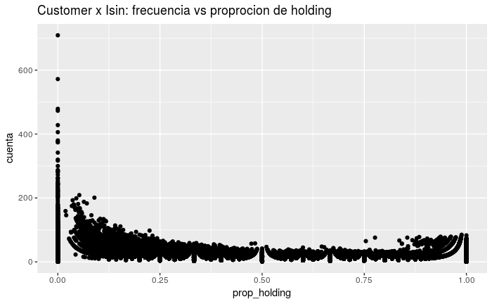

```r
hold_customer_x_isin %>%
    ggplot() + geom_point(aes(x = prop_holding, y = cuenta))  +
    ggtitle("Customer x Isin: frecuencia vs proprocion de holding")
```

- Vale la pena revisar esos Customer x Isin con frecuencias mayores a 200; ver si podemos manipular las predicciones.

[figure not shown]

```r
holding_isin %>%
    filter(prop_holding<0.01 | prop_holding>0.995) %>%
    mutate(prop_holding = ceiling(prop_holding)) %>%
    count(prop_holding)
```

| prop_holding | n |
| --- | --- |
| 0 | 1034 |
| 1 | 198 |

- Hay bonos que casi siempre se retienen, y aparecen con una frecuencia no despreciable. ¿Que caracteriza a estos bonos?
- Hay bonos que nunca se retienen, pero tienen una frecuencia mucho menor. Podría deberse a simple aleatoriedad.
- Una gran cantidad de bonos se trafica de forma poco frecuente y con variacióne en la proporción de holding.

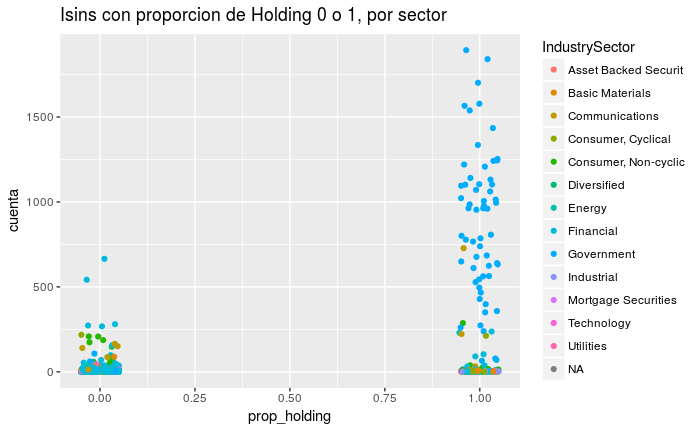

```r
isin_ceros_unos <- holding_isin %>%
            filter(prop_holding==0 | prop_holding > 0.995) %>%
            inner_join(isin, by = "IsinIdx")
isin_ceros_unos %>%
    ggplot() +
    geom_jitter(aes(x= prop_holding,
                    y = cuenta, color = IndustrySector), width = 0.05) +
    ggtitle("Isins con proporcion de Holding 0 o 1, por sector")
```

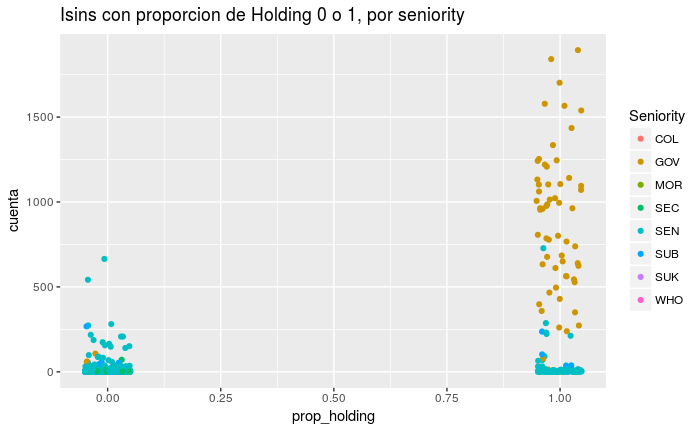

```r
isin_ceros_unos %>%
    ggplot() +
    geom_jitter(aes(x= prop_holding,
                    y = cuenta, color = Seniority), width = 0.05) +
                    # y = cuenta, color = paste(Seniority,IndustrySector)), width = 0.05) +
    ggtitle("Isins con proporcion de Holding 0 o 1, por seniority")
```

- Hay un patron claro. Lo ideal seria retirar toda la data sobre esas acciones del modelo, porque solo estan causando confusion respecto a otros niveles de sus covariables . Y manipular las predicciones a mano.

### Implicancias para challenge

```r
challenge$CustomerIdx %>% unique %>% length()
```

```
[1] 2495
```

```r
trade$CustomerIdx %>% unique() %>% length()
```

```
[1] 3439
```

```r
challenge$IsinIdx %>% unique() %>% length()
```

```
[1] 18265
```

```r
trade$IsinIdx %>% unique() %>% length()
```

```
[1] 27305
```

- No todos los Isins ni todos los clientes estan en Challenge

```r
isin_ceros_unos %>%
    filter(cuenta > 250) %>%
    select(IsinIdx) %>% distinct() %>%
    inner_join(select(challenge, IsinIdx) %>% distinct(), by = "IsinIdx")
```

| IsinIdx |
| --- |
| 3960 |
| 3810 |
| 2146 |
| 15313 |
| 2156 |
| 2158 |
| 3813 |
| 3362 |
| 3574 |
| 317 |

[output cut: 3 more lines]

- :( solo hay 382 predicciones a los que les podemos meter mano directamente

```r
isin_ceros_unos %>%
    filter(cuenta > 250) %>%
    select(IsinIdx) %>% distinct() %>%
    inner_join(select(challenge, IsinIdx) %>% distinct(), by = "IsinIdx") %>%
    inner_join(trade, by = "IsinIdx") %>% dim()
```

```
[1] 11689     8
```

Modificando archivo

- Al modificar esto manualmente, se pasa de 0.72120 a 0.72107; hacerlo manualmente es casi lo mismo que que lo haga el modelo

La frecuencia del número de transacciones por cliente: - La mediana es 55, el 3er cuartil es 574. La media 1966. El maximo es 154077!

La mayor parte de clientes hace menos

### Apuntes

- Resolver el TradeStatus Holding, que indica algo distinto de lo que debería.
  - *Holding: Some of our Customer have a legal obligation to report at a regular frequency (monthly, quarterly) what they have in their portfolio. This information is represented in our database as a serie of transaction happening on those reporting dates: if Customer suddenly has a holding of 10M on 31St of Jan in a given Bond, we will record a Buy transaction for 10M on 31st of Jan. If on the 31st of Match the holding is now 5M, we will record a Sell transaction for 5M on the 31st of March. Those are not real transaction but just a way to represent Customer’s holdings.*
  - 67% de las operaciones en Trade son de estatus holding.